# Excel

## Data Type in Excel

- Text Data Type:
  - This is used for any kind of text or string data.
  - `'13151592601`
- Number Data Type:
  - Ideal for numerical data that you want to perform calculations on.
  - `5e+5`,`8,900`
  - At most 16 digits
- Date and Time Data Type:
  - To enter a date, type it into a cell (e.g., 01/11/2024). Excel formats and aligns it to the right.
  - `1900/1/1` is the default start point
- Boolean Data Type:
  - Simply type `TRUE` or `FALSE` into a cell. Excel treats these as logical values.
- Error Data Type:
  - Excel generates this automatically when there's an error in a formula or operation (e.g., `#DIV/0!`).
    - `#####` : Do not have enough space to show content
    - `#VALUE!` : Wrong data type
    - `#DIV/0` : Divide by 0
    - `#NAME?` : Wrong function name / use string type value without quotation mark
    - `#N/A` : Return NA / None from a function
    - `#REF!` : Reference area is empty
    - `#Num!` : Invalid number have been used

## Shortcut in Excel

- `alt + enter` : start a new line within a block
- `ctrl + enter` : input for multiple blocks
- `ctrl + ;` : insert current date
- `ctrl + shift + ;` : insert current time
- `ctrl + G`: goto
- `ctrl + F`: find
- `ctrl + H`: substitute
- `ctrl + E`: Flash fill

## Custom Format

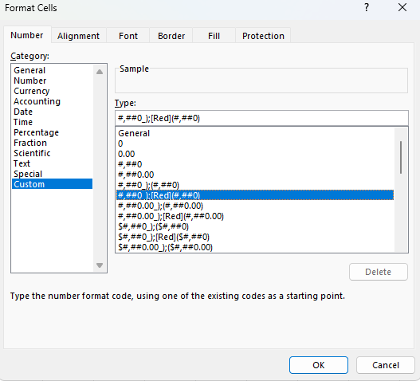

1. Accessing Custom Format Settings
   - Select the Cells: Click on the cell or range of cells you want to format.
   - Open Format Cells Dialog:
     - Right-click on the selected cells and choose `Format Cells`, or
     - Go to the Home tab, click the dropdown arrow in the `Number` group, and select `More Number Formats` at the bottom of the list.
2. Creating a Custom Format
   - Navigate to Custom Format:
     - In the `Format Cells` dialog box, go to the `Number` tab.
     - Select `Custom` from the category list.
   - Type Your Custom Format:
     - In the `Type` box, you can create your custom format. Excel provides several built-in format codes, but you can also type your own.
     - Custom format codes consist of symbols that define how you want to display the content. For example:
       - `"Total: "#,##0` - This will display numbers with a thousands separator and prefix them with the word 'Total:'.
       - `0.00%` - This displays numbers as a percentage with two decimal places.
       - `yyyy-mm-dd` - This formats dates in a specific year-month-day format.
3. Preview and Apply:
   - As you type, the 'Sample' box shows how your data will look with the custom format.
   - Once satisfied with the format, click 'OK' to apply it to the selected cells.

## Data Validation

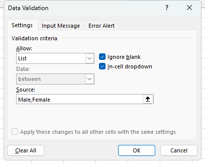

1. Select the Cells:
   - Click on the cell or range of cells where you want to apply data validation.
2. Access Data Validation Settings:
   - Go to the `Data` tab on the Ribbon.
   - Click on `Data Validation` in the `Data Tools` group.
3. Configure Validation Criteria:
   - In the `Data Validation` dialog box, under the `Settings` tab, you can specify the criteria.
   - Choose the type of validation from the `Allow` dropdown menu. Options include:
     - `Whole Number`: Restricts the cell to integer values.
     - `Decimal`: Allows decimal numbers within a specified range.
     - `List`: Limits the cell to a list of predefined items.
     - `Date`: Restricts the cell to date values.
     - `Time`: Restricts the cell to time values.
     - `Text Length`: Limits the text length in a cell.
     - `Custom`: Uses a formula to determine what is allowed.
   - Set the specific criteria (like minimum and maximum values for numbers, a source range for a list, etc.).
4. Input Message (Optional):
   - Switch to the `Input Message` tab.
   - You can create a message that will appear when the cell is selected, guiding users on what to input.
5. Error Alert (Optional):
   - Go to the `Error Alert` tab.
   - Configure an error message that appears when someone enters invalid data.
   - You can choose the style of the error message (Stop, Warning, Information), and customize the title and content of the message.
6. Apply the Validation:
   - Click `OK` to apply the data validation rules to the selected cells.

## Basic Data Table

### Description

- These are the simplest form of tables in Excel, primarily used for **data entry and storage**.
- They consist of rows and columns where each row represents a record and each column represents a field of the record.

### Usage

- Ideal for maintaining records like employee details, product lists, or daily transactions.
- They serve as the source for more complex tables and reports.

### Feature

- May include features like data validation, sorting, and basic filtering.

## Calculated Summary Table

### Description

- These tables are used to summarize and analyze data from Basic Data Tables.
- They typically include calculations, such as sums, averages, counts, or more complex formulas.

### Usage

- Useful for creating summaries like monthly sales totals, average expenses, or performance metrics.
- Often used in conjunction with PivotTables or other Excel analysis tools.

### Feature

- Include calculated columns or rows.
- May utilize functions like `SUMIF`, `AVERAGEIF`, `VLOOKUP`, etc.

## Report Tables

### Description

- Report Tables are advanced tables designed for reporting and presenting data in a **user-friendly** and visually appealing manner.
- They often combine data from multiple sources and include advanced features like `PivotTables`, `charts`, and conditional formatting.

### Usage

- Ideal for creating `dashboards`, annual reports, or performance presentations.
- Used for making data-driven decisions and presenting data to stakeholders.

### Feature

- Incorporate `dynamic charts` and `graphs`.
- Utilize advanced data tools like `PivotCharts`, `slicers`, and `timelines` for interactive data exploration.

[figure not shown]

### Common function

- `COUNTIF()`:
  - `COUNTIF(A:A,A2)`
  - `COUNTIF(B$2:B2,B2)`
- `IFERROR()`:
  - `IFERROR(H13/I13,"NA")`
- `STDEVP`
  - `IF(ABS(J16)-AVERAGE(J:J)>2*STDEVP(J:J),"Outlier","-")`
- `LEFT()`,`RIGHT()`,`MID()`
- `Find()`:
  - `LEFT(A2,FIND("/",A2)-1)`
- `SUBSTITUTE()`, `REPT()`,`TRIM()`
- `LEFTB()`,`SEARCHB()`,`LENB()`